# 分割表の分析

小野裕介

2017年4月6日

## r×cのクロス表：例えばカフェイン摂取量と婚姻状況の関係

＊婚姻状況ごとのカフェイン消費量を示した次のようなデータがある(Dalgaard 2002：邦訳p.68)。

表：婚姻状況ごとのカフェイン消費量(mg)

|  | 0 | 1－150 | 151－300 | ＞300 |
| --- | --- | --- | --- | --- |
| Married | 652 | 1537 | 598 | 242 |
| Prev.married | 36 | 46 | 38 | 21 |
| Single | 218 | 327 | 106 | 67 |

＊データを行列(matrix)として作る。nrow=3は行(row)の数である。byrow=Tは、行ごとに、つまり横方向に、数値を入れていくということである。ちなみに、数学でいう「行列」の「行」は、英語ではrowである。

```r
caff.marital　<-　matrix(c(652,1537,598,242,36,46,38,21,218,327,106,67), nrow=3, byrow=T)
```

＊行(row)と列(column)にラベルをつける

```r
colnames(caff.marital) <- c("0","1-150","151-300",">300")
rownames(caff.marital) <- c("Married","Prev.Married","Single")
```

＊独立性に関するカイ2乗検定を行う。

```r
chisq.test(caff.marital)
```

```
##
##  Pearson's Chi-squared test
##
## data:  caff.marital
## X-squared = 51.6556, df = 6, p-value = 2.187e-09
```

＊点図表で傾向を図示してみる。tは行列の行と列を入れ替える。

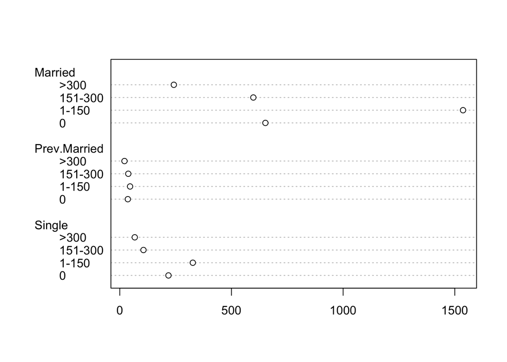

```r
dotchart(t(caff.marital))
```

```r
t(caff.marital)
```

```
##         Married Prev.Married Single
## 0           652           36    218
## 1-150      1537           46    327
## 151-300     598           38    106
## >300        242           21     67
```

## ２×２分割表の分析：例えば治療の効果

＊次のような臨床試験の結果について考える (Daggard2002：邦訳p.125)。

表：頚椎の変形性関節症に対する赤外線治療の効果

|  | 効果あり | 効果なし | 合計 |
| --- | --- | --- | --- |
| 治療群 | 9 | 3 | 12 |
| 対照群 | 4 | 9 | 13 |
| 合計 | 13 | 12 | 25 |

＊比率の差の検定として行うことができる。２項分布の正規分布による近似がなされる。ちなみに、lewitt.machinというのは、このデータの元になったLewittとMachinの研究にちなんでいるだけである（Dalgaard 2002：邦訳p.125）。

```r
lewitt.machin.success <- c(9,4)
lewitt.machin.total <- c(12,13)
prop.test(lewitt.machin.success, lewitt.machin.total)
```

```
##
##  2-sample test for equality of proportions with continuity
##  correction
##
## data:  lewitt.machin.success out of lewitt.machin.total
## X-squared = 3.2793, df = 1, p-value = 0.07016
## alternative hypothesis: two.sided
## 95 percent confidence interval:
##  0.01151032 0.87310506
## sample estimates:
##    prop 1    prop 2
## 0.7500000 0.3076923
```

＊フィッシャーの正確検定を行えば、近似の問題はなくなる。データは行列にする必要がある。

```r
lewitt.machin <- matrix(c(9,4,3,9), nrow=2)
fisher.test(lewitt.machin)
```

```
##
##  Fisher's Exact Test for Count Data
##
## data:  lewitt.machin
## p-value = 0.04718
## alternative hypothesis: true odds ratio is not equal to 1
## 95 percent confidence interval:
##   0.9006803 57.2549701
## sample estimates:
## odds ratio
##   6.180528
```

＊カイ2乗検定を行う。これは、2×2の分割表では比率の差の検定と同じことになる。

```r
chisq.test(lewitt.machin)
```

```
##
##  Pearson's Chi-squared test with Yates' continuity correction
##
## data:  lewitt.machin
## X-squared = 3.2793, df = 1, p-value = 0.07016
```

## リスク比：例えばコホート研究における介入の効果

＊神経筋協調訓練と女性アスリートのACL損傷に関する前向きコホート研究( Mandelbaum et al. Effectiveness of Neuromuscular and Proprioceptive Training Program in Preventing Anterior Cruciate Ligament Injuries in Female Athletes, Am J Sports Med. 2005;33:7:1003-1010)を考える。

表：2000年度におけるACL損傷者(Mandelbaum et al. 2005：1006)

|  | 損傷人数 | 非損傷人数 | 合計 |
| --- | --- | --- | --- |
| 介入群 | 2 | 1039 | 1041 |
| 対照群 | 32 | 1873 | 1905 |
| 合計 | 34 | 2912 | 2946 |

＊ACL損傷者の群間の割合に関して、フィッシャーの正確検定を行う。

```r
x<-matrix(c(2,32,1039,1873),nrow=2)
fisher.test(x)
```

```
##
##  Fisher's Exact Test for Count Data
##
## data:  x
## p-value = 9.098e-05
## alternative hypothesis: true odds ratio is not equal to 1
## 95 percent confidence interval:
##  0.0130763 0.4433609
## sample estimates:
## odds ratio
##  0.1127129
```

＊リスク比とその95％信頼区間を計算する。Mandelbaum et al. (2005：1005)によれば、リスク比は0.114で95％信頼区間は0.03－0.48であるとされる。ここでは、中澤港氏が作成したfmsb(cran)のriskrationいう関数を利用してそれを確認する。

＊治療群で1041人の中で2人が損傷、対照群で1905人の中32人で損傷という今回の場合は、次のように指定する。リスク比は(2/1041)/(32/1905)である。

```r
library(fmsb)
riskratio(2,32,1041,1905)
```

```
##            Disease Nondisease Total
## Exposed          2       1039  1041
## Nonexposed      32       1873  1905
```

```
##
##  Risk ratio estimate and its significance probability
##
## data:  2 32 1041 1905
## p-value = 0.0003025
## 95 percent confidence interval:
##  0.02746489 0.47628908
## sample estimates:
## [1] 0.1143732
```

## オッズ比：例えばケースコントロール研究による暴露の効果

＊患者対照（ケース・コントロール）調査におけるオッズ比の推定について考える。

表：サリドマイド服用の有無とアザラシ肢症発症の有無（柳井2008：192）

|  | アザラシ肢症発症 | 発症なし | 合計 |
| --- | --- | --- | --- |
| サリドマイド服用あり | 90 | 2 | 92 |
| サリドマイド服用なし | 22 | 186 | 208 |
| 合計 | 112 | 188 | 300 |

＊カイ２乗検定

```r
x<-matrix(c(90,22,2,186),nrow=2)
chisq.test(x)
```

```
##
##  Pearson's Chi-squared test with Yates' continuity correction
##
## data:  x
## X-squared = 203.8357, df = 1, p-value < 2.2e-16
```

＊library(fmsb)のoddsratioを利用してオッズ比の95%信頼区間を計算する。

```r
oddsratio(90,22,2,186)
```

```
##            Disease Nondisease Total
## Exposed         90          2    92
## Nonexposed      22        186   208
## Total          112        188   300
```

```
##
##  Odds ratio estimate and its significance probability
##
## data:  90 22 2 186
## p-value < 2.2e-16
## 95 percent confidence interval:
##    87.54238 1653.43532
## sample estimates:
## [1] 380.4545
```

＊発症ありにおいて、暴露が90、非暴露が22、発症なしにおいて暴露が２，非暴露が186ならば、オッズ比は、(90/22)/(2/186)=90×186/(2×22)と計算される。 「発症あり」と「発症なし」を暴露をまたいで乗じて（分割表上では、たすきがけになる）、 暴露群発症ありが含まれる項を分子にする、と覚えてもよい。

## マクネマー(McNemar)の検定：対応のある2標本の母比率の差

＊柳井(2008：193)の例：入院期間が2週間の患者が40名いたとする。入院後1週間は個室病棟、残りの1週間は一般病棟で過ごした。最初の1週間（個室病棟）と残りの1週間（一般病棟）に関しての転倒数は以下のようであった。

表：前半の個室病棟と後半の一般病棟での転倒人数

|  | 一般病棟で転倒あり | 一般病棟で転倒なし | 合計 |
| --- | --- | --- | --- |
| 個室病棟で転倒あり | 10 | 15 | 25 |
| 個室病棟で転倒なし | 5 | 10 | 15 |
| 合計 | 15 | 25 | 40 |

＊前半1週間(個室病棟)では40人中25人が転倒した。後半1週間(一般病棟)では40人中15人が転倒した。

＊マクネマーの検定では、前半の個室病棟では転倒しなかったが後半の一般病棟では転倒した人の数(5人)と、逆に、前半の個室病棟では転倒があったが後半の一般病棟では転倒がなかった人の数(15人)に着目して分析する。

＊マクネマーの検定

```r
falls <- matrix(c(10,15,5,10), nrow=2, byrow=T)
mcnemar.test(falls)
```

```
##
##  McNemar's Chi-squared test with continuity correction
##
## data:  falls
## McNemar's chi-squared = 4.05, df = 1, p-value = 0.04417
```

＊対馬（2007）の例

表：脳卒中患者における麻痺の回復

|  | 退院時に麻痺あり | 退院時に麻痺なし | 合計 |
| --- | --- | --- | --- |
| 入院時に麻痺あり | 68 | 10 | 78 |
| 入院時に麻痺なし | 20 | 0 | 20 |
| 合計 | 88 | 10 | 98 |

＊98人の患者に関して、入院時には78人に麻痺があった。同一の98人の患者に関して、退院時には麻痺が88人であった。

＊マクネマーの検定

```r
paralysis <-  matrix(c(68,10,20,0),nrow=2,byrow=T)
mcnemar.test(paralysis)
```

```
##
##  McNemar's Chi-squared test with continuity correction
##
## data:  paralysis
## McNemar's chi-squared = 2.7, df = 1, p-value = 0.1003
```

### 参考文献

- 対馬栄輝(2007)『SPSSで学ぶ医療系データ解析』, 東京図書, 2007.
- 中澤港(2007)『R による保健医療データ解析演習』, ピアソン・エデュケーション, 2007.
- 柳井晴夫(2008)「仮説検定とその実際」, 福井次矢編集『臨床研究マスターブック』, 医学書院, 2008.
- Dalgaard, Peter (2002) Introductory Statistics with R, Springer-Verlag New York Inc. =岡田昌史監訳『Rによる医療統計学』, 丸善, 2007.